## Question - Does “Garbage Time” work as popular opinion concieves it to?

The question that I had for this NFL data set has it’s motivation in a common acknowledged phenomena that occurs when a team is either very head or behind with little time left to go. In these circumstances, the likelihood of turning the game around is near nil. Colloquially` this phenomena is called ‘garbage time’. Traditionally, when a game enters garbage time, the assumption is that it is significantly easier for the attacking team to score points, as the defending team is no longer focused on reducing scoring opportunities, but instead to run out the clock and avoid injuries.

However, as a statistician, I was curious if the data backed up this commonly held belief. I was unable to find serious statistical analysis of this phenomena and wished to see if I was able to find a firm conclusion one way or another.

For the data cleaning portion this analysis, I started by looking for missing data that would need to be imputed. There were several entries with NA for defenders in box, pass rushers, and absolute yardline number. These were imputed with the most common entry, the mean or the median, for the NA values.

## Method

My approach to answering this question was to first see if I could define a good metric for ‘garbage time’, and additionally see if I could find an acceptable metric to judge performance of any given play, to see if plays made in garbage time generated positive or negative value. Looking at the data set, I was able to find a reasonable stand-in for performance on a play, through the statistic of expected points added per play.

However, garbage time, our first metric, was not as easily available. I needed to engage in feature engineering to create an acceptable metric, which was the next step of my process.

Lastly, I focused on looking at plays made in the fourth quarter only, as there is generally enough time remaining in a game near regardles of the score differential, for comebacks to be possible, in any other quarter.

### Feature Engineering

The first step in feature engineering the garbage-time variable was thinking how I believed it would be the most appropriate to design something representative of the ratio of time remaining to score differential. This cuts to the direct issue of having relatively little time remaining to break past a potentially insurmountable score differential, by measuring both of these aspects directly.

Calculation of the score differential was relatively easy, as it was just the absolute value of the difference between home and away scores for any given play.

Calculation of the time remaining was a little more difficult, but essentially amounted to turning a text string into a numerical vector, representing time remaining in seconds.

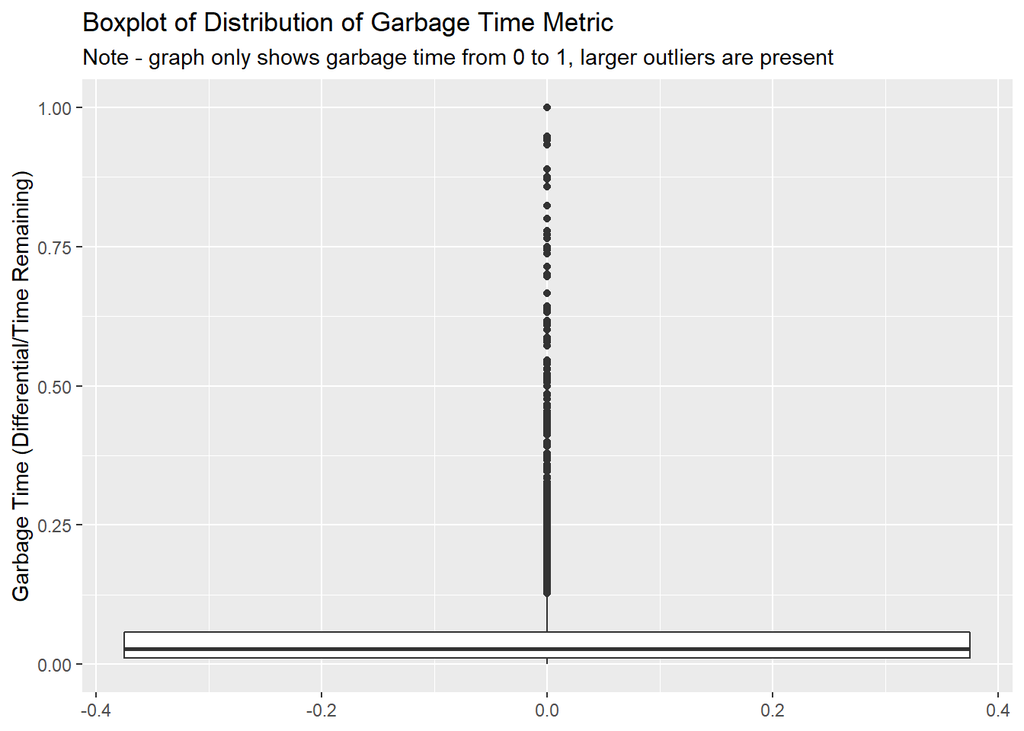

Boxplot of Distribution of Garbage Time Metric

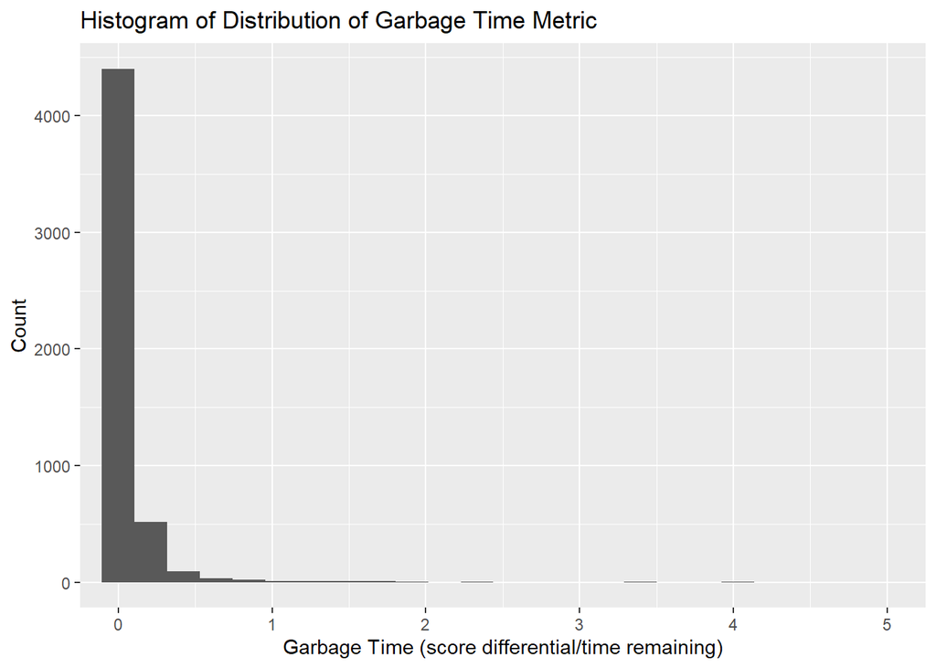

Histogram of Distribution of Garbage Time Metric

Due to this, I considered further feature engineering, wherein I created a binary cutoff of garbage time, treating it as a categorical variable. This is because the extreme nonlinearity and outliers in the distribution of garbage time values made me hesitant to use linear modeling.

When looking at transforming our garbage time variable, and considering that it had some extreme outliers, I felt that using the median would be a very reasonable cutpoint for small versus large garbage time values, indicating whether or not a given play was made in ‘garbage time’.

|  | epa |  |  |
| --- | --- | --- | --- |
| Predictors | Estimates | CI | p |
| (Intercept) | -0.04 | -0.08 – 0.01 | 0.095 |
| gtime | -0.20 | -0.32 – -0.08 | **0.001** |
| Observations | 5117 |  |  |
| R<sup>2</sup> / R<sup>2</sup> adjusted | 0.002 / 0.002 |  |  |

|  | epa |  |  |
| --- | --- | --- | --- |
| Predictors | Estimates | CI | p |
| (Intercept) | -0.02 | -0.07 – 0.02 | 0.321 |
| gtime | -0.42 | -0.64 – -0.19 | **<0.001** |
| gtime^2 | 0.02 | 0.00 – 0.03 | **0.028** |
| Observations | 5117 |  |  |
| R<sup>2</sup> / R<sup>2</sup> adjusted | 0.003 / 0.003 |  |  |

```
## Analysis of Variance Table
##
## Model 1: epa ~ gtime
## Model 2: epa ~ gtime + I(gtime^2)
##   Res.Df   RSS Df Sum of Sq      F  Pr(>F)
## 1   5115 13413
## 2   5114 13400  1    12.655 4.8295 0.02802 *
## ---
## Signif. codes:  0 '***' 0.001 '**' 0.01 '*' 0.05 '.' 0.1 ' ' 1
```

I chose to look at both of the forms of my ‘garbage time’ variable when modeling the question, to see if my results hold up through both versions of the feature.

Furthermore, when looking at a second linear model that consists of the additional 2nd degree effect of garbage time, we see a real improvement in our model fit, as compared to our first model. This is as expected, given the extreme nonlinearity of our distribution of garbage time data.

|  | epa |  |  |
| --- | --- | --- | --- |
| Predictors | Estimates | CI | p |
| (Intercept) | -0.00 | -0.07 – 0.06 | 0.952 |
| mg2 [large] | -0.10 | -0.19 – -0.01 | **0.024** |
| Observations | 5117 |  |  |
| R<sup>2</sup> / R<sup>2</sup> adjusted | 0.001 / 0.001 |  |  |

```
## Analysis of Variance Table
##
## Model 1: epa ~ gtime
## Model 2: epa ~ gtime + I(gtime^2)
## Model 3: epa ~ mg2
##   Res.Df   RSS Df Sum of Sq       F   Pr(>F)
## 1   5115 13413
## 2   5114 13400  1    12.655  4.8295 0.028021 *
## 3   5115 13428 -1   -27.688 10.5668 0.001159 **
## ---
## Signif. codes:  0 '***' 0.001 '**' 0.01 '*' 0.05 '.' 0.1 ' ' 1
```

## Results

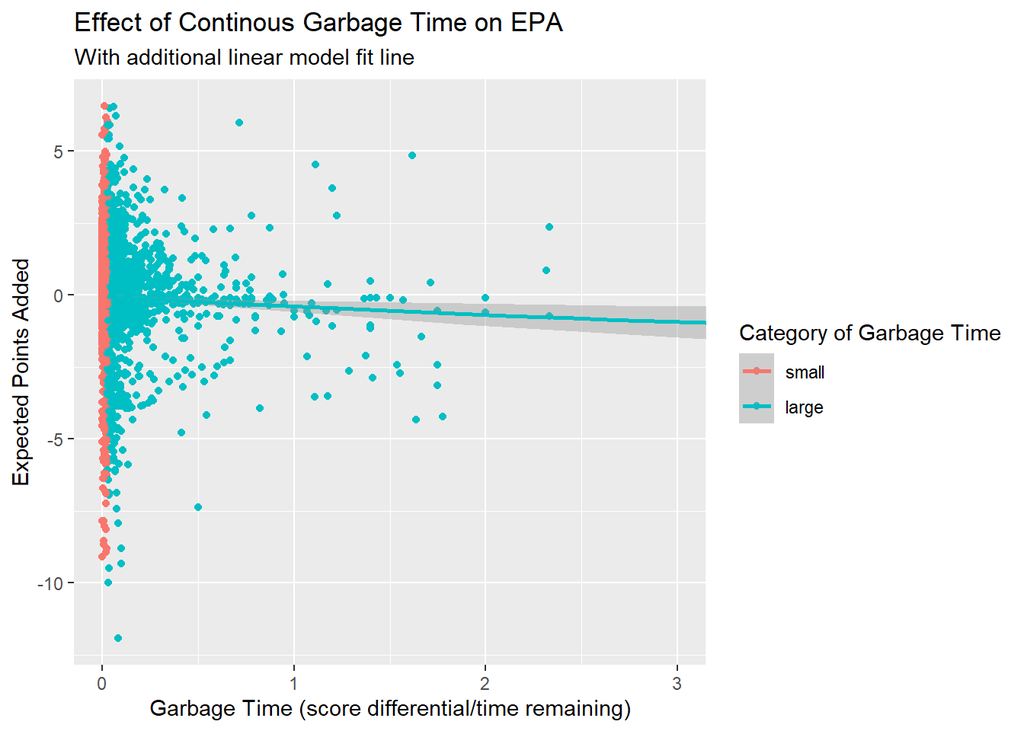

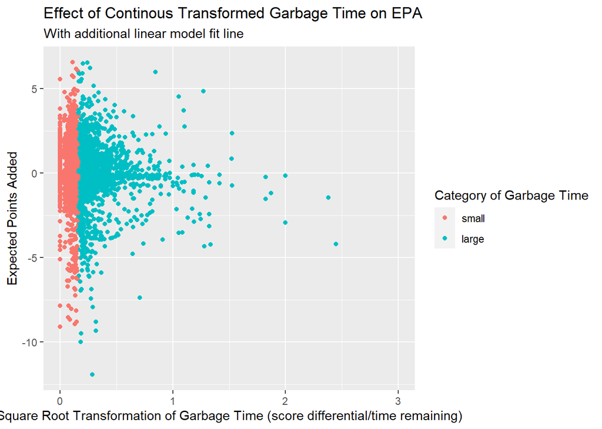

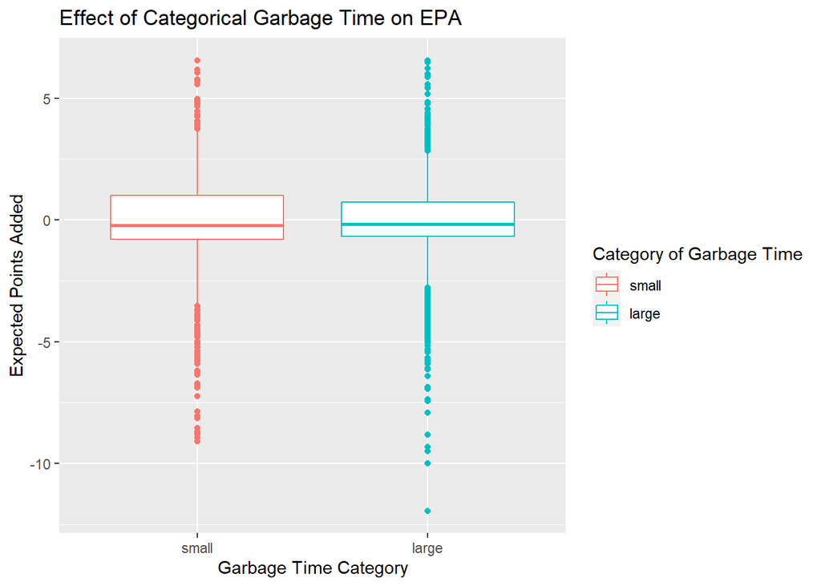

## Discussion of problems

There was one primary challenge with answering this specific question with this specific dataset, which was the feature engineering and the statistical thinking and modeling around that feature. Engineering a novel feature that corresponds to a commonly held belief or phenomena in Football was not as simple as it seemed. First, there was very little in the way of previously done statistical analysis on the concept of ‘garbage time’, and there was little domain specific expertise available when I researched whether or not various professional football thinkers had plumbed the issues depths. Furthermore, there was a good deal of critical thinking required to determine how best to quantify the garbage time metric I ended up developing, especially considering that the feature that I had engineered was significantly non-linear in distribution, with a large amount of zero-inflation as well. I believe that due to these issues, I was able to learn a great deal about how to handle non-linear data distributions, and I felt pleasantly surprised to find what seemed to be a statistically significant result that opposed my initial beliefs about the problem.